```python
%matplotlib inline
import numpy as np
import matplotlib
import matplotlib.pyplot as plt
import scipy
from scipy import stats
from matplotlib import pylab
from pylab import *
from tabulate import tabulate

plt.rcParams["figure.figsize"] = (15,10)
```

# Lab 3: Asking Statistical Questions

## Problem 1

In this problem we are looking at meta-data: data about experimental conditions. In this particular case we are considering the temperature of an experimental setup.

Let us assume that our control system tries to keep the temperature raound 12K, and our temperature readings are normally distributed with a standard deviation of 0.4K.

We occasionally get anomalously high or low readings; this can be due to (1) the control system failing, or (2) glitches in the thermometry that give us a false reading. We would like to throw out all (1) cases because we know our data is not reliable here. Additionally, to be extra cautious we would like to throw out readings that may just be glitches in thermometry.

As a concrete example, we shall generate temperature readings that are normally distributed about 12K with standard deviation 0.4K; we throw in the anomalously high or low readings {10.0K, 10.3K, 2.1K,0.0K, 0.0K, 15.6K, 22.3K, 12.7K}, which we will refer to as 'bad data'. Below we display our distribution:

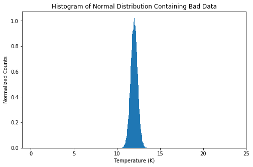

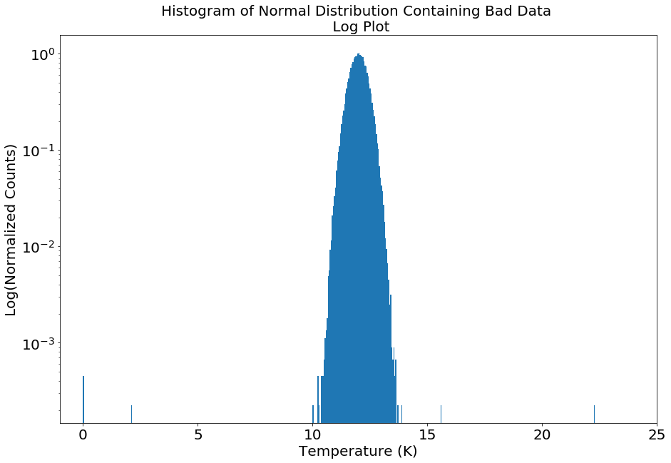

```python
#generate 100k random points with Gaussian distribution, mu = 12, sigma = 0.4
good = stats.norm.rvs(loc = 12, scale = 0.4, size = 100000)
bad = np.array([10.0,10.3,2.1,0.0,0.0,15.6,22.3,12.7])

alldata = np.append(good,bad) #put all data into one array so we can plot 'density histogram' to visualize bad data

figure(figsize = (8,5))
plt.hist(alldata,500,density = True)
plt.xlim([-1,25])
plt.title('Histogram of Normal Distribution Containing Bad Data')
plt.xlabel('Temperature (K)')
plt.ylabel('Normalized Counts')

figure()
plt.hist(alldata,500,density = True)
plt.tick_params(labelsize = 20)
plt.yscale('log')
plt.xlim([-1,25])
plt.title('Histogram of Normal Distribution Containing Bad Data \n Log Plot',size = 20)
plt.xlabel('Temperature (K)',size = 20)
plt.ylabel('Log(Normalized Counts)',size = 20)


plt.show()
```

The statistical question we ask is:

*If I only keep data within the range [11.6K,12.4K] (1 standard deviation from the desired mean), what percentage of my 'good' data do I keep (true positive) and what percentage of my 'good' data do I discard (true negative)? Furthermore, what percentage of my 'bad' data do I keep (false positive) and what percentage do I discard (false negative)?*

We reiterate that 'good' data refers to data that was collected when we knew our control system and thermometry were working properly. 'Bad' data refers to data that was collected when either of these systems failed.

Data that belongs to our 'good' set is referred to as 'true' because we know this data accurately reflects physical conditions that we desire for our experiment. Data that belongs to our 'bad' set is referred to as 'false' because it consists of anomalies due to hardware malfunction.

Notice that since we are dealing with temperature fluctuations that are normally distributed, **there is still a non-zero chance we correctly measure a value that is undesirabley too high or too low for experimental conditions.** The fact that we generate normally distributed data using a python algorithm *and then throw in additional high/low readings* is meant to simulate the fact that hardware malfunction does not adhere to the specific gaussian statistics associated with the physically real temperature fluctuations, and so readings associated with hardware malfunction must be generated outside of the algorithm use to simulate real temperature distribution. This does not imply that all anomalously high or low data points necessarily originated from some sort of malfunction.

Data is further categorized as 'positive' or 'negative' if it passes, or does not pass, the statistical test to which it is subjected. In this case the test is simple: we are asking whether or not a particular reading falls within a certain range ([11.6K,12.4K]).

We answer our question by implementing the code below:

```python
#good data is when our control system & thermometry were working
#bad data is when either of these systems failed
# Recall good = stats.norm.rvs(loc = 12, scale = 0.4, size = 100000)
# Recall bad = np.array([10.0,10.3,2.1,0.0,0.0,15.6,22.3,12.7])

#testRange is function that takes in a range as a parameter and returns
#an array [truePositive,trueNegative,falsePositive,falseNegative]
def testRange(minThreshold,maxThreshold):

    truePositive = 0 #number of good data within the range we check
    trueNegative = 0 #number of good data not within the range we check

    falsePositive = 0 #number of bad data within the range we check
    falseNegative = 0 #number of bad data not within the range we check

    #below we look through our good data to count truePositive and trueNegative:
    for i in range(len(good)):
        reading = good[i]
        if(reading >= minThreshold) and (reading <= maxThreshold):
            truePositive = truePositive + 1
        else:
            trueNegative = trueNegative + 1

    #below we look through bad data to count falsePositive and falseNegative:
    for i in range(len(bad)):
        reading = bad[i]
        if(reading >= minThreshold) and (reading <= maxThreshold):
            falsePositive = falsePositive + 1
        else:
            falseNegative = falseNegative + 1

    return [truePositive,trueNegative,falsePositive,falseNegative]

#printTruthTables is function that takes in an array of length4; meant to be used on an array from testRange above
#will print out the truth tables
def printTruthTables(arrayTruth):

    truePositive = arrayTruth[0]
    trueNegative = arrayTruth[1]
    falsePositive = arrayTruth[2]
    falseNegative = arrayTruth[3]

    truePosPercent = str((truePositive/len(good))*100)+'%'
    trueNegPercent = str((trueNegative/len(good))*100)+'%'
    falsePosPercent = str((falsePositive/len(bad))*100)+'%'
    falseNegPercent = str((falseNegative/len(bad))*100)+'%'

    print('Truth Table for our Meta Data: \n')
    print(tabulate([['True',truePositive,trueNegative],['False',falsePositive,falseNegative]],headers =['','Positive','Negative'],tablefmt = 'orgtb1' ))
    print('\n \n')
    print('Rate of Discarding Data by Type(Good/Bad):\n')
    print(tabulate([['True',truePosPercent,trueNegPercent],['False',falsePosPercent,falseNegPercent]],headers =['','Positive','Negative'],tablefmt = 'orgtb1' ))

    return

array1 = testRange(11.6,12.4) #we are looking at data within one standard deviation
printTruthTables(array1)
```

```
Truth Table for our Meta Data:

         Positive    Negative
-----  ----------  ----------
True        68467       31533
False           0           8



Rate of Discarding Data by Type(Good/Bad):

       Positive    Negative
-----  ----------  ----------
True   68.467%     31.533%
False  0.0%        100.0%
```

We see that for this particular data set, if we restrict ourselves to considering data from within one standard deviation of the expected mean, we managed to eliminate all of the 'bad' data (100% of our False data did not pass the test--the outcome was Negative). However, observe that we also threw out a significant portion of our 'good' data: 31.5%.

Now, if our experiment requires that our temperature be as close to 12K as possible and needs the precision to be less than or equal to +/- 0.4K, then we may not care that we threw out all of those data points. But if our experiment does not need to be that precise, we ended up throwing out some good data that may have been useful.

Observe what happens if we change our range and ask the question:

*If I only keep data within the range [11.2K,12.8K] (2 standard deviation within the mean), what percentage of my 'good' data do I keep (true positive) and what percentage of my 'good' data do I discard (true negative)? Furthermore, what percentage of my 'bad' data do I keep (false positive) and what percentage do I discard (false negative)?*

Let's find out below:

```python
#see line 102 for definitions of functions called below
array2 = testRange(11.2,12.8) #we are looking at data within two standard deviations
printTruthTables(array2)
```

```
Truth Table for our Meta Data:

         Positive    Negative
-----  ----------  ----------
True        95430        4570
False           1           7



Rate of Discarding Data by Type(Good/Bad):

       Positive    Negative
-----  ----------  ------------------
True   95.43%      4.569999999999999%
False  12.5%       87.5%
```

We see that although we have kept most (95%) of our 'good' data, we have not eliminated all of the 'bad' data. Hence, we see that if we make our range be symmetric about the mean, having a larger threshold for keeping data (larger range) means that we **increase both how much 'good' data we keep and how much 'bad' data we keep**.

This means we need to find a balance between how much good data we are willing to throw out for how much bad data we manage to discard. Notice that since the expected distribution of meta-data is known, we always know roughly what percentage of the 'good' data we keep since we can integrate the pdf from $-\infty$ to *minThreshold* and from *maxThreshold* to $+\infty$ to find the percentage of good data that will be discarded.

In this particular case we know exactly what the largest 'bad' data point is below the mean, and what the smallest 'bad' data point is above the mean; hence we can construct a range that will maximize how much 'good' data we keep while we throw out all of the 'bad' data:

*If I only keep data within the range [10.4K,12.6K], what percentage of my 'good' data do I keep (true positive) and what percentage of my 'good' data do I discard (true negative)? Furthermore, what percentage of my 'bad' data do I keep (false positive) and what percentage do I discard (false negative)?*

```python
#see line 102 for definitions of functions called below
array3 = testRange(10.4,12.6)
printTruthTables(array3)
```

```
Truth Table for our Meta Data:

         Positive    Negative
-----  ----------  ----------
True        93479        6521
False           0           8



Rate of Discarding Data by Type(Good/Bad):

       Positive    Negative
-----  ----------  ------------------
True   93.479%     6.521000000000001%
False  0.0%        100.0%
```

In this case we've managed to throw out all of the bad data while keeping 93% or our good data. However, notice that our range is not symmetric about the mean and is constructed so that we keep data that falls in the large gap that exists in our 'bad' data set.

This was possible because we knew exactly where our instrumentation failed us (we knew exactly what our bad set looked like). In reality, this information may not be known and so it may not be possible to construct a range that can discard bad data so efficiently. **Additionally, picking a range that is not symmetric about the mean causes the average temperature for the data we choose to evaluate to not be 12K, which may or may not be a problem depending on our specific experiment**.

# Problem 2

In this problem our statistical question will aim to work backwards from a desired significance. We know we want measurements that corresponds to at least $5\sigma$ significance (see Lab 1 for explanation of significance); given a particular background distribution, which measurements should we hope for?

In this particular example we will be looking for asteroids by taking images of the night sky. When we look at the alignment of stars on subsequent images, we obtain a 2D Gaussian distribution of positional uncertainty due to atmospheric and instrumental effects (ignoring proper motion). In other words, if we histogram how far stationary stars appear to move, we get the following distribution:

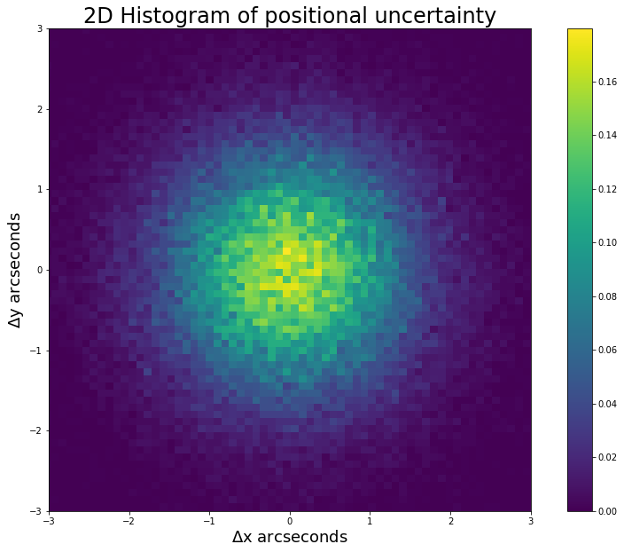

```python
#Code Below is copied directly from 'Lab 3' instructions created for Phys 434 Autum 2019
a = np.vstack((stats.norm.rvs( scale = 1, size = 100000), stats.norm.rvs( scale = 1, size = 100000)))
a.shape
fig, ax = plt.subplots(1, 1)
h = ax.hist2d(a[0,:],a[1,:],bins=100, density=True);
ax.set_aspect('equal', 'box')
plt.xlim([-3 , 3])
plt.ylim([-3 , 3])
plt.title("2D Histogram of positional uncertainty", fontsize = 24)
plt.ylabel("$\Delta$y arcseconds", fontsize = 18)
plt.xlabel("$\Delta$x arcseconds", fontsize = 18)
plt.colorbar(h[3], ax=ax)
plt.show()
```

When we look for asteroids, we look for true movement between images. If we identify an object that looks like it's moving between subsequent images, we measure $\Delta x$ and $\Delta y$ in arcseconds, and the distance corresponding to how far the object travelled is $d = \sqrt{\Delta x^2 + \Delta y^2}$.

Now, as explained above, there is a positional uncertainty in both the $x$ and $y$ directions, and both the $\Delta x$ and $\Delta y$ background measurements are normally distributed about 0 arcseconds with standard deviation 1 arcsecond.

Recall from lab 1:

> Let $x$ and $y$ be continuous random variables that are normally distributed, both having a mean of 0 and a standard deviation of $\sigma$.

> If $x$ and $y$ are uncorrelated then $d = \sqrt{y^2+x^2}$ is also a continuous random variable, and it is said to be Rayleigh distributed; its probability density function is:

> $$f(d) = \frac{d}{\sigma^2} e^{\frac{-d^2}{2\sigma^2}}, \hspace{2mm} x\geq0.$$

Hence we say can say that **the background distribution for the distance measurement of movement between subsequent images is a Rayleigh distribution with rate paramater 1 arcsecond**.

When looking for asteroids, we are interested in objects that appear to move a large distance between subsequent images. Hence, our threshold for 'signal like' will be a lower bound.

We can now form our statistical question:

*Given that our background for distance measurements is a Rayleigh distribution with rate parameter 1 arcsecond, and we define our signal type to be large distances, what is the minimum distance measurement that would yield 5 σ significance?*

To answer the above question we must simply call the **percent point function** for the Rayleigh distribution (recall that the percent point function is the inverse of the **cumulative density function**. See Lab 1 for detailed explanation).

See below for the numerical implementation:

```python
fiveSigma = 1 - stats.norm.cdf(5) #probability associated with 5sigma for LARGE Distances
minDistance = stats.rayleigh.ppf(1 - fiveSigma, loc = 0, scale = 1)
print('minimum distance for 5 \u03C3 signifiance = ', minDistance, 'arcseconds')
```

```
minimum distance for 5 σ signifiance =  5.489079776034238 arcseconds
```

# Problem 3

In this problem we consider the shadow left by the moon in the cosmic ray background. We want to know how significant this shadow effect is when determining the cosmic ray background for gamma-ray detection experiments.

We assume we have a cosmic ray background with a rate of 1 cosmic ray/minute (arrivals are random in time). If we can observe where the moon is when it is not too close to the horizen--a window of 8 hours per night--and we observe for 15 different nights, what is the signficance of seeing 6800 cosmic rays? That is, since our total observation time is $8 \space hours \times 60 \frac{minutes}{hour} \times 15 = 7200 \space minutes$, we ask what is the significance of $\frac{6800 \space rays}{7200 \space minutes}= 0.944 \space rays/min$?

## 3.1 Determining Experimental Setup and Background

In order to ask a statistical question that makes sense, we must first determine our experimental setup and our background.

Since we are *counting* cosmic rays, we can assume that our cosmic ray distribution is Poisson (see Lab 1 and Lab 2 for explanation of Poisson). Hence we know that our **cosmic ray background for 1 minute is a Poisson distribution with $\lambda = 1\space ray/min$**.

Now, we are trying to determine how significant the moon's shadow is in our calculation of the cosmic ray background; in a single night, the starkest contrast we could detect would result from *averaging* our signal and *averaging* our background *over the course of 8 hours* (see lab 2 on the effects of averaging on signal to noise ratios).

Our cosmic background rate of 1 ray/minute was obtained by counting cosmic rays with no regard for whether the moon's shadow had an effect. Since we can only observe the moon during the night (and only for 8 hours each night), *averaging over periods longer than 8 hours would reduce our signal to noise ratio* because our noise--the cosmic ray background over multiple days and nights--would contain data that may have been affected by the moon's shadow (but we did not know this was the case).

Hence, **we consider different nights of observing the moon's shadow as different trials**.

To summarize:

> to determine our background distribution, we must average 8 hours of 1-minute backgrounds and we must include a trials factor of 15. That is, we must average the Poisson distribution with λ=1 ray/min for 480 minutes, and then multiply that distribution by 15. We will use this background to determine the significance of 6800 rays/7200 min = 0.944 rays/min.

Recall that to average a distribution we simply have to convolve the distribution with itself and then rescale the x-axis.

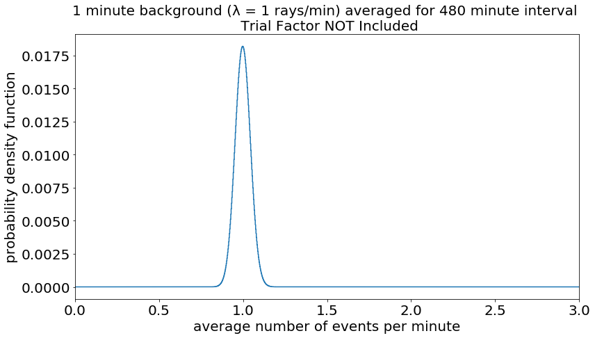

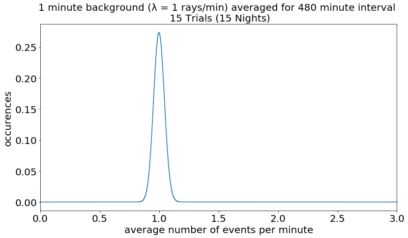

```python
#below we average the cosmic ray background for 480 minutes

avgCosmic = 1 #assume background is Poisson with 1 rays/minute
x = np.arange(0,30,1) #we make the tail long enough to avoid errors in convolutions
background1min = stats.poisson.pmf(x, avgCosmic)

#below we convolve the background for 480 minute interval
multDays = background1min
for i in range(479):
    multDays = np.convolve(background1min,multDays)


figure(figsize = (13,7))
plt.title('1 minute background (\u03bb = 1 rays/min) averaged for 480 minute interval \n Trial Factor NOT Included', size = 20)
plt.xlabel('average number of events per minute', size = 20)
plt.ylabel('probability density function',size = 20)
xplot1 = np.arange(0,29,0.0020833)
plt.step(xplot1,multDays)
plt.xlim([0,3])
plt.tick_params(labelsize = 20)

figure(figsize = (13,7))
plt.title('1 minute background (\u03bb = 1 rays/min) averaged for 480 minute interval \n 15 Trials (15 Nights)', size = 20)
plt.xlabel('average number of events per minute', size = 20)
plt.ylabel('occurences',size = 20)
xplot1 = np.arange(0,29,0.0020833)
plt.step(xplot1,multDays*15)
plt.xlim([0,3])
plt.tick_params(labelsize = 20)

plt.show()
```

## 3.2 Stating and Answering our Statistical Question

Notice that the distribution for 15 nights is not really a probability density function, but rather a measure of roughly how many nights are expected to produce a particular signal (where the signal is measured in rays/minute and it is an average over 480 minutes).

So instead of asking the question *what is the probability that my background produced by 15 nights could have produced an average of 0.944 rays per minute or less?*, we ask:

*what is the expected number of nights, out of 15, that might produce an average signal of 0.944 rays/minute or less?*

Notice that our signal-type consists of rates smaller than what we measured because we are interested in values that suggest a blocking of cosmic rays.

To answer this question we must integrate the 15 day background from x = 0 to x = 0.944, which is the same as integrating a one-night probability distribution from x = 0 to x = 0.944 and multiplying by 15:

```python
#recall that a poisson convolved with itself is still a poisson distribution
#the average poisson will be centered around the new rate: (1 ray/min)*480 minutes = 480 ray/interval
#we recognize that by averaging we rescaled the x-axis, so we can integrate the poisson centered at 480
#but now we must divide by 480 since the spacing between the possibilities is 1/480 of the spacing
#before averaging.
#notice that since we use the poisson centered at 480, we need to integrate up to 0.944*480 = 453.333
avg1night = stats.poisson.cdf(453.333,480)/480

expNumNights = 15*avg1night #expected number of nights out of 15 that might produce signal of 0.944 or less

print('Expected number of nights that might produce \n average signal of 0.944 rays/minute or less = ', expNumNights)
```

```
Expected number of nights that might produce
 average signal of 0.944 rays/minute or less =  0.0035160607055313917
```

Since the above result is less than 1, we can consider it a probability and state:

*The probability that my 15-night background produced an average signal of 0.944 rays/minute or less is 0.352%*

We can now turn this into a significance:

```python
sig = stats.norm.ppf(0.0035161)
print('significance of measuring 6800 rays in 7200 minutes = ', sig,'\u03C3')
```

```
significance of measuring 6800 rays in 7200 minutes =  -2.6953155491958447 σ
```

Recall that the negative sign means that our signal would have to be to the left of the mean, which makes sense since we are looking for shadows.

Hence our significance is about $2.7\sigma$ (the sign is implied by the signal type we consider).

```python
!jupyter nbconvert --to html Phys434_thalyapaleologu_lab3.ipynb
```

```
[NbConvertApp] Converting notebook Phys434_thalyapaleologu_lab3.ipynb to html
[NbConvertApp] Writing 505578 bytes to Phys434_thalyapaleologu_lab3.html
```